# King - Per Marcus

Per Marcus

November 7, 2018

### Assignment

#### Setup

The aim of this assignment has been to show if a diffence exists between two testgroups, `a` and `b`. The groups consists of users of a game where 80 % of the users belong to group `a` and 20 % belong to group `b`.

Two data sets have been used for the assignment, `assignment` and `activity`. Both have been called from Googles cloud services using R and the package `BigRQuery`. Since the amount of data was large, a sample of 1000 users have been used. These 1000 users was randomly selected from the `assignment` table and then all data connected to these users have been called from the `activity` table. These 1000 unique users had a total of 24646 different observations.

The assignment will be split in two parts. The first part will handle simple statistics to understand if conversion and puchases are larger in group A or B, both in proportion and in frequency. I will also present plots on the distribution of `gameends`, `purchases` and `total_puchases` of set time period.

The second part will present modelling and test if one can estimate the probability if players in each group will `convert` or not.

### Simple statistcs

Following section will present the plots and statistics. Plots will be presented to visualize the results and statistics will be presented to give inference.

#### Plots/Visualisation

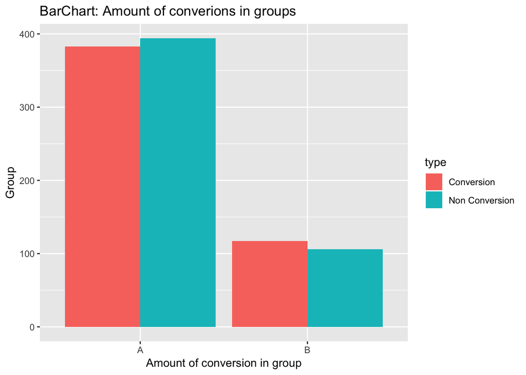

Amount of conversion in groups implies that it is more common to convert in group B than in group A.

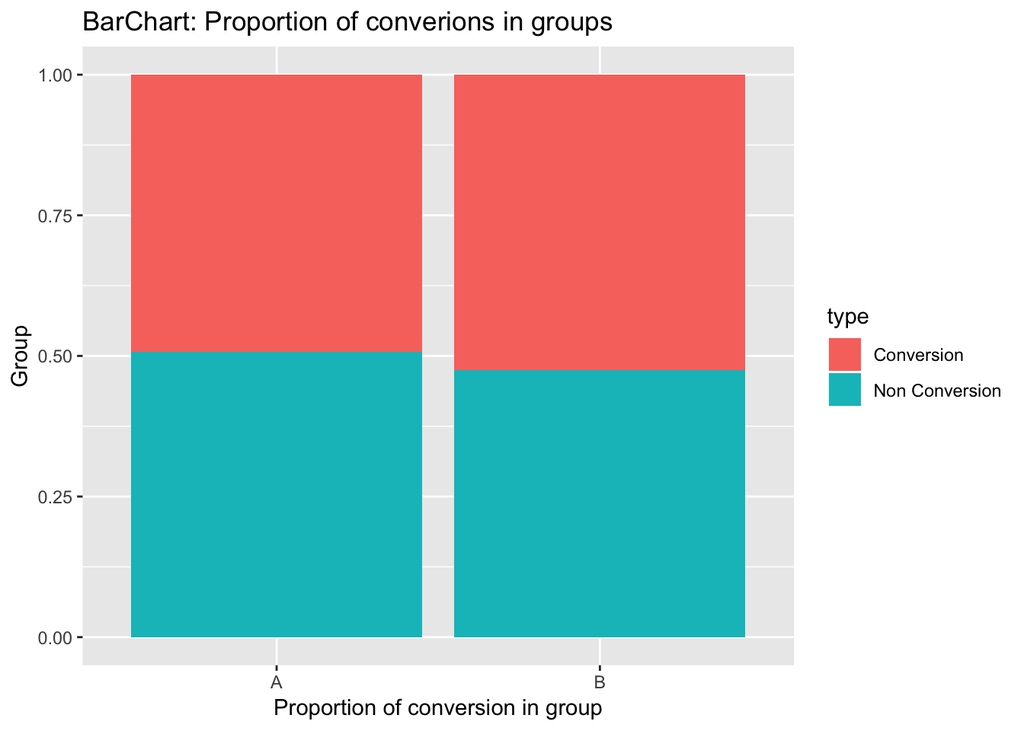

Proportion of conversion in groups show that it is more common to convert in group B than in group A.

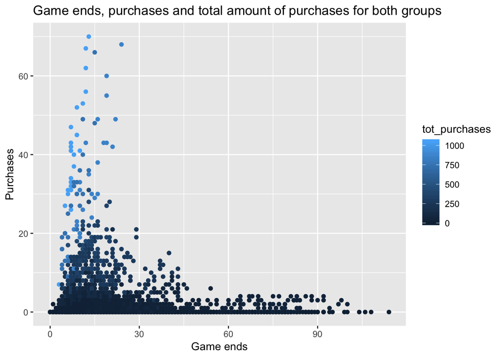

The plot above shows that purchases are more common for players whom play between 0 and 30 `gameends` per day. It is also these players whom use the most `purchases` in total. It also seems as if the linear relationship in this data, `gameends` between 0 and 30, is stronger than if one would look at the data as a whole. This group would be interesting to take a closer look at.

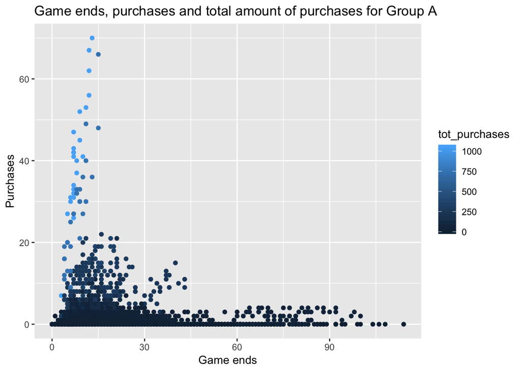

The behaviour of group A is similar to that of the total, which is to be expected since group A contains 80 % of the data.

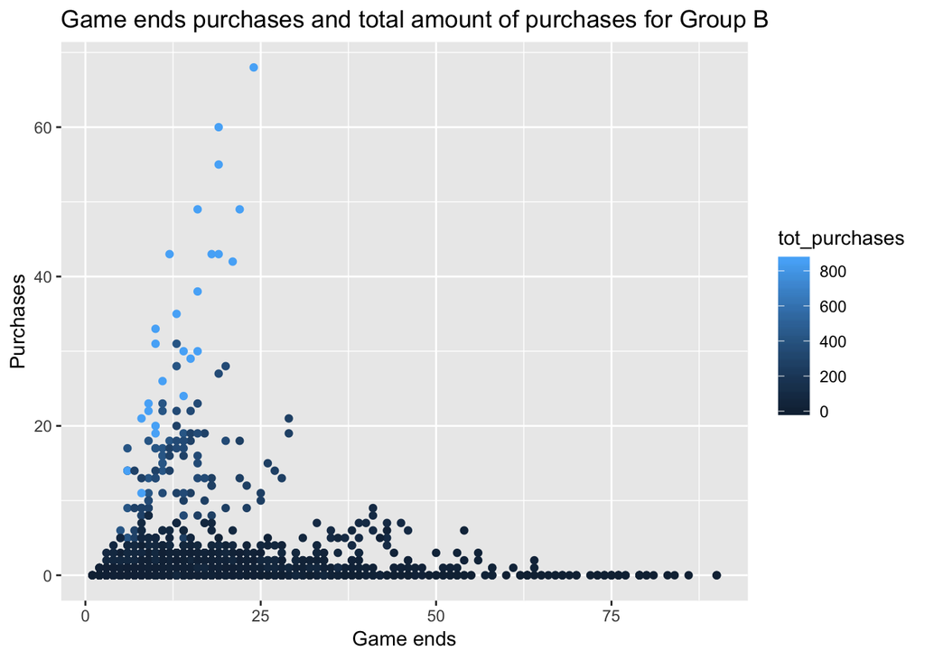

Behaviour of group B seems to slightly differ in linear relationship from group A, where `gameends` 0 to 25 seems so give slightly more purchases.

#### Statistics

To check if the groups differ simple t.tests have been performed. Group A is defined by X and group B is defined by Y.

Difference in `conversion`:

```
##
##  Welch Two Sample t-test
##
## data:  group_a$conversion and group_b$conversion
## t = -5.1619, df = 8908.5, p-value = 2.498e-07
## alternative hypothesis: true difference in means is not equal to 0
## 95 percent confidence interval:
##  -0.05440771 -0.02445824
## sample estimates:
## mean of x mean of y
## 0.4914874 0.5309203
```

Difference in `purchases`:

```
##
##  Welch Two Sample t-test
##
## data:  group_a$purchases and group_b$purchases
## t = -5.3735, df = 7218.7, p-value = 7.963e-08
## alternative hypothesis: true difference in means is not equal to 0
## 95 percent confidence interval:
##  -0.3436951 -0.1599589
## sample estimates:
## mean of x mean of y
## 0.4957176 0.7475446
```

With statistical certainty, we can say that group B has a higher conversion rate and a higher purchase rate.

#### Results from statistics

The results tell us that, using the gameversion which was used for group B will be better than using the one for group A.

### Modelling

The aim of my study in the modelling part will be to see if we can estimte `conversion` based on the data that exists within the activity data table. `Conversion` is set if a user has ever done a purchase within game.

For modelling purposes the data table was split in two parts, training and validation/test.

#### Concerns about data for the modelling

Before I started modelling the data I realized that some of the analysis which I considered to do was not possible. I thought it would be interesting to see if the total number of played games had impact on `conversion`, but the table does not contain all data from `installation_date` to first `activity_date`. This means that this analysis is not possible.

To get around this problem I choose to look at the total amount of `gameends` per player during the set time frame to see if that had any impact on `conversion`.

#### Modelling groups

The modelling was done for both of the groups, one modell for group A and one modell for group B. I applied a simple GLM-logit model to estimate the probability of `conversion` for players based on `total_gameends`, where `total_gameends` is the total amount of `gameends` during the time of the study.

The aim of the models is to see if players in group A or group B have a higher probability to `convert`.

#### Validation of models

The validation on modelling has been done by RMSE, accuracy and confussion matrix. Results from the two models are as follows.

###### Results of model for Group A

RMSE:

```
## [1] 0.6870587
```

Confusion matrix:

```
##           Reference
## Prediction  0  1
##          0 23 12
##          1 64 62
```

Error estimation:

```
##       Accuracy          Kappa  AccuracyLower  AccuracyUpper   AccuracyNull
##   5.279503e-01   9.710744e-02   4.478394e-01   6.070134e-01   5.403727e-01
## AccuracyPValue  McnemarPValue
##   6.543061e-01   4.912740e-09
```

###### Results of model for group B

RMSE:

```
## [1] 0.6979824
```

Confusion matrix:

```
##           Reference
## Prediction  0  1
##          0  2  3
##          1 16 18
```

Error estimation:

```
##       Accuracy          Kappa  AccuracyLower  AccuracyUpper   AccuracyNull
##    0.512820513   -0.033472803    0.347802209    0.675819219    0.538461538
## AccuracyPValue  McnemarPValue
##    0.685875340    0.005905392
```

Becasue of this it is my recommendation to add data to the model for a more accurat results in regards to estimation of `conversion`.

### Overall

Game version for group B shows better results. For this reason, it is recommended to use version B.

For further analysis it would be interesting to check if the average number of `gameends` per player differed between the two groups. I would also like to check if the number of `purchases` was different depending on how many `gameends` the players did in each group. This was shortly mentioned in the plots section. In that section we can see visually that players with 0 to 30 `gameends` have a higher tendency for `conversion` and `purchases`. Splitting the data in different groups based on `gameends` and creating inference on these individual groups could give an understanding in what groups would be better to target in regards to `converion` and `purchases`.

Regarding modelling more data or a different setup, such as the previously mentioned data split, is needed to better estimate the probability of `conversion`.

Reagaring what was tested, I quess it is the number of games a player can play for free per day.

//Per Marcus